# Advanced Graphics in R

2015-06-08

## BP Oil Spill

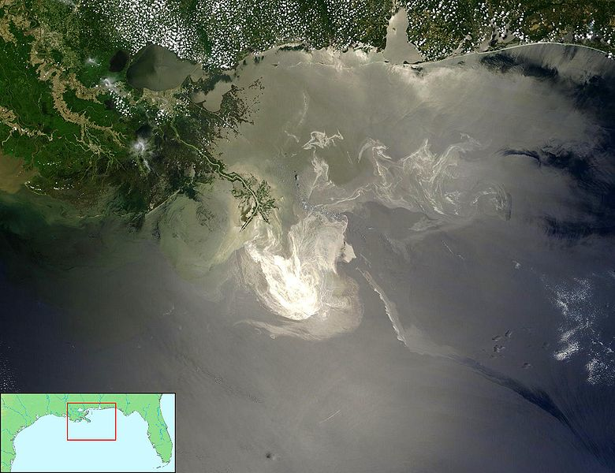

## Data Sets

1. NOAA Data
   - National Oceanic and Atmospheric Administration
   - Temperature and Salinity Data in Gulf of Mexico
   - Measured using Floats, Gliders and Boats
2. US Fisheries and Wildlife Data
   - Animal Sightings on the Gulf Coast
   - Birds, Turtles and Mammals
   - Status: Oil Covered or Not

Both data sets have geographic coordinates for ever observation

## Loading NOAA Data

```r
x <- ls()
noaa <- "http://www.public.iastate.edu/~hofmann/looking-at-data/data/noaa.rdata"
if (!file.exists("noaa.rdata")) download.file(noaa, "noaa.rdata")
load("noaa.rdata")
setdiff(ls(), x)
```

```
## [1] "boats"   "floats"  "gliders" "noaa"    "rig"     "x"
```

## Floats Data

```r
str(floats)
```

```
## 'data.frame':    10332 obs. of  14 variables:
##  $ callSign      : Factor w/ 11 levels "Q4901043","Q4901044",..: 1 1 1 1 1 1 1 1 1 1 ...
##  $ Date_Time     : Factor w/ 73 levels "5/24/2010","5/26/2010",..: 30 30 30 30 30 30 30 30 30 30 ...
##  $ JulianDay     : num  2455390 2455390 2455390 2455390 2455390 ...
##  $ Time_QC       : int  1 1 1 1 1 1 1 1 1 1 ...
##  $ Latitude      : num  24.8 24.8 24.8 24.8 24.8 ...
##  $ Longitude     : num  -88 -88 -88 -88 -88 ...
##  $ Position_QC   : int  1 1 1 1 1 1 1 1 1 1 ...
##  $ Depth         : int  2 4 6 8 10 12 14 16 18 20 ...
##  $ Depth_QC      : int  1 1 1 1 1 1 1 1 1 1 ...
##  $ Temperature   : num  29.8 29.6 29.5 29.5 29.5 ...
##  $ Temperature_QC: int  1 1 1 1 1 1 1 1 1 1 ...
##  $ Salinity      : num  36.6 36.6 36.6 36.6 36.6 ...
##  $ Salinity_QC   : int  1 1 1 1 1 1 1 1 1 1 ...
##  $ Type          : Factor w/ 1 level "Float": 1 1 1 1 1 1 1 1 1 1 ...
```

## Floats

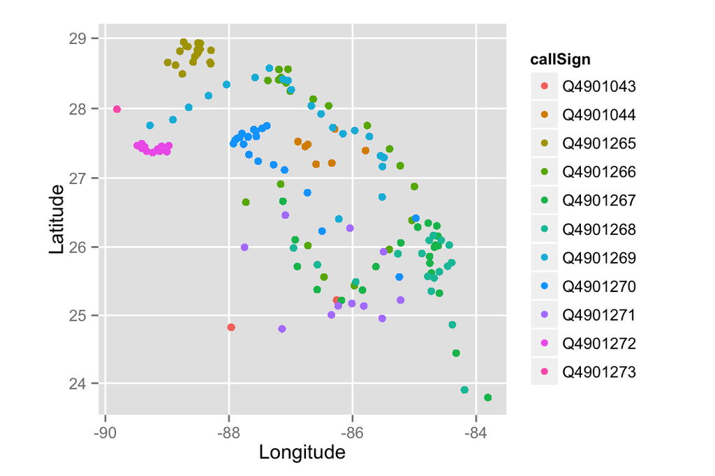

```r
library(ggplot2)
qplot(Longitude, Latitude, colour = callSign, data = floats) +
  coord_map()
```

## A note on `qplot()` versus `ggplot()`

- `qplot()` makes many assumptions to save you some typing.
- Although it's often useful for quick, interactive, exploratory data analysis; eventually you'll want the full flexibility of `ggplot()`.
- `qplot()` assumes variable names are *aesthetics* (a mapping from data to visual elements), but with `ggplot()`, you have to specify them.

```r
ggplot(data = floats, aes(x = Longitude, y = Latitude, colour = callSign)) +
  geom_point() + coord_map()
```

- [RStudio's ggplot2 cheatsheet](http://www.rstudio.com/wp-content/uploads/2015/03/ggplot2-cheatsheet.pdf) provides a great visual of this difference.

## Gliders Data

```r
str(gliders)
```

```
## 'data.frame':    369384 obs. of  14 variables:
##  $ callSign      : Factor w/ 10 levels "48900","48901",..: 2 2 2 2 2 2 2 2 2 2 ...
##  $ Date_Time     : Factor w/ 74 levels "5/28/2010","5/29/2010",..: 16 16 16 16 16 16 16 16 16 16 ...
##  $ JulianDay     : num  2455351 2455351 2455351 2455351 2455351 ...
##  $ Time_QC       : int  1 1 1 1 1 1 1 1 1 1 ...
##  $ Latitude      : num  27.9 27.9 27.9 27.9 27.9 ...
##  $ Longitude     : num  -84 -84 -84 -84 -84 ...
##  $ Position_QC   : int  1 1 1 1 1 1 1 1 1 1 ...
##  $ Depth         : int  3 4 5 6 7 8 9 10 11 12 ...
##  $ Depth_QC      : int  1 1 1 1 1 1 1 1 1 1 ...
##  $ Temperature   : num  28.1 27.8 27.8 27.7 27.7 ...
##  $ Temperature_QC: int  1 1 1 1 1 1 1 1 1 1 ...
##  $ Salinity      : num  35.4 35.4 35.4 35.3 35.3 ...
##  $ Salinity_QC   : int  1 1 1 1 1 1 1 1 1 1 ...
##  $ Type          : Factor w/ 1 level "Glider": 1 1 1 1 1 1 1 1 1 1 ...
```

## Gliders

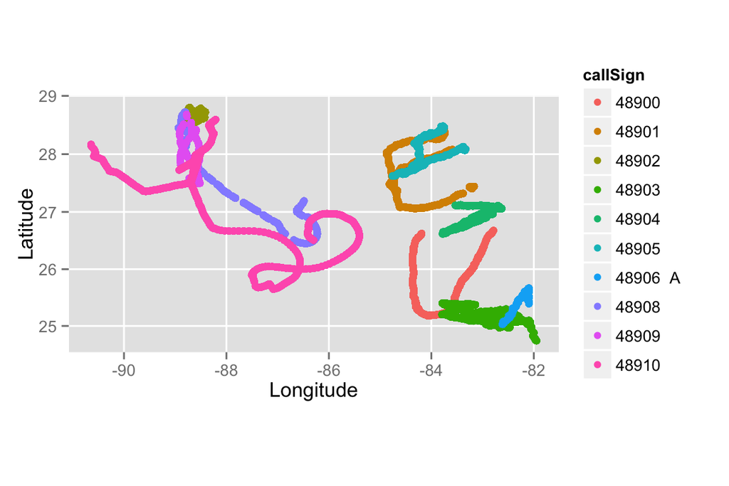

```r
ggplot(data = gliders, aes(x = Longitude, y = Latitude, colour = callSign)) +
  geom_point() + coord_map()
```

## Boats Data

```r
str(boats)
```

```
## 'data.frame':    106735 obs. of  14 variables:
##  $ callSign      : Factor w/ 2 levels "WTEO","WTER": 1 1 1 1 1 1 1 1 1 1 ...
##  $ Date_Time     : Factor w/ 43 levels "4/22/2010","4/23/2010",..: 12 12 12 12 12 12 12 12 12 12 ...
##  $ JulianDay     : num  2455330 2455330 2455330 2455330 2455330 ...
##  $ Time_QC       : int  1 1 1 1 1 1 1 1 1 1 ...
##  $ Latitude      : num  26.3 26.3 26.3 26.3 26.3 ...
##  $ Longitude     : num  -87 -87 -87 -87 -87 ...
##  $ Position_QC   : int  1 1 1 1 1 1 1 1 1 1 ...
##  $ Depth         : int  2 3 4 5 6 7 8 9 10 11 ...
##  $ Depth_QC      : int  1 1 1 1 1 1 1 1 1 1 ...
##  $ Temperature   : num  27.8 27.8 27.7 27.7 27.7 ...
##  $ Temperature_QC: int  1 1 1 1 1 1 1 1 1 1 ...
##  $ Salinity      : num  36.4 36.4 36.4 36.4 36.4 ...
##  $ Salinity_QC   : int  1 1 1 1 1 1 1 1 1 1 ...
##  $ Type          : Factor w/ 1 level "Boat": 1 1 1 1 1 1 1 1 1 1 ...
```

## Boats

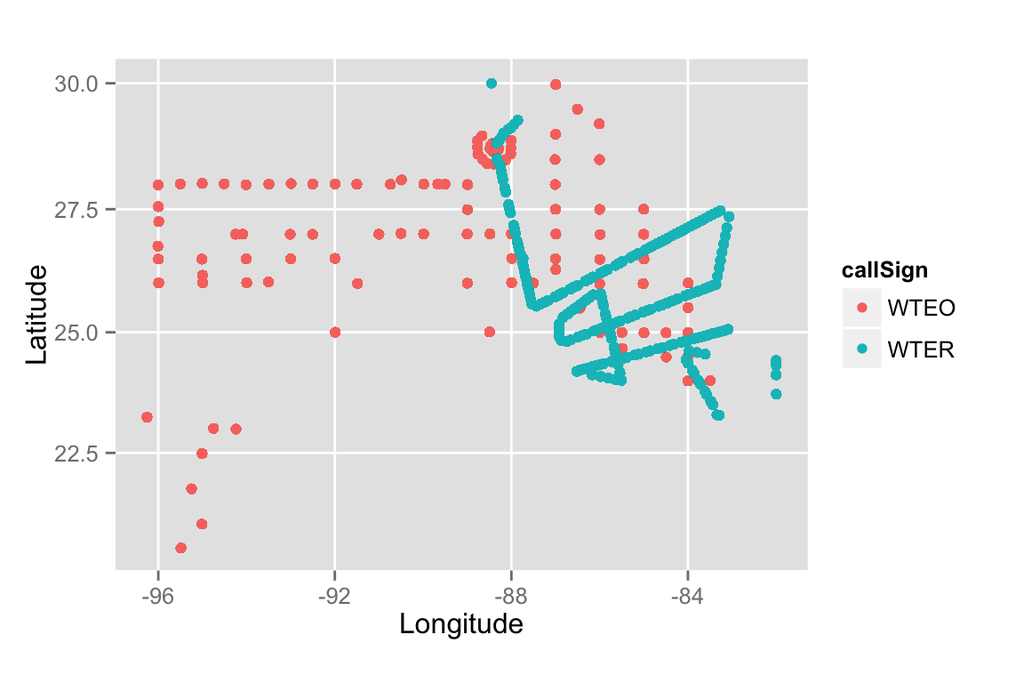

```r
ggplot(data = boats, aes(x = Longitude, y = Latitude, colour = callSign)) +
  geom_point() + coord_map()
```

## Provide some context

- All of this data comes from the same geographic region.
- It'd be nice if we could *overlay* this information onto a map!
- This is where ggplot2's layering idea becomes useful.

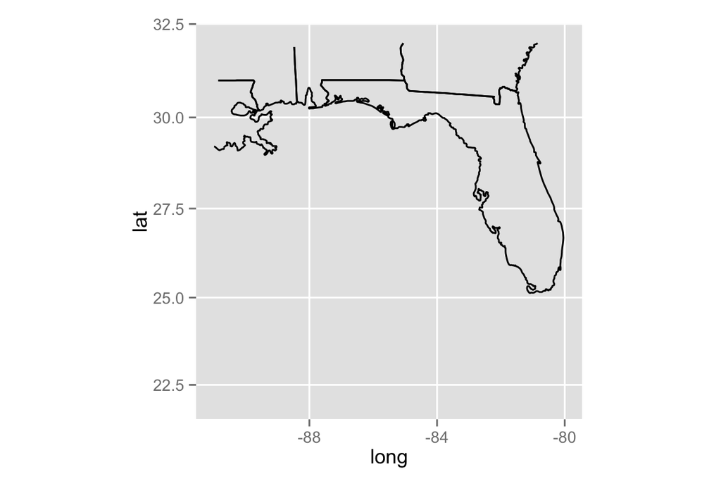

```r
states <- map_data("state")
map_outline <- ggplot() +
  geom_path(data = states, aes(x = long, y = lat, group = group)) +
  xlim(c(-91, -80)) + ylim(c(22,32)) + coord_map()
map_outline
```

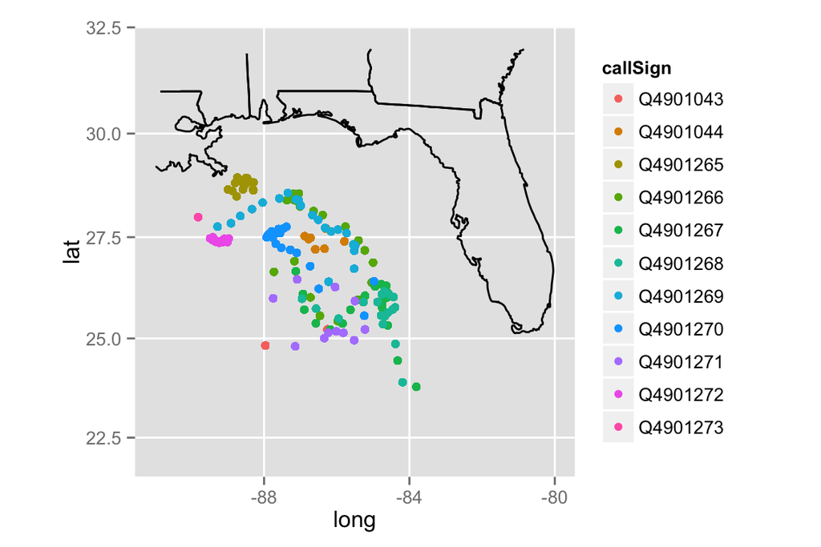

```r
map_floats <- map_outline +
  geom_point(data = floats, aes(x = Longitude, y = Latitude, colour = callSign))
map_floats
```

```r
rig # location of BP Oil rig
```

```
##         x        y
## 1 -88.366 28.73663
```

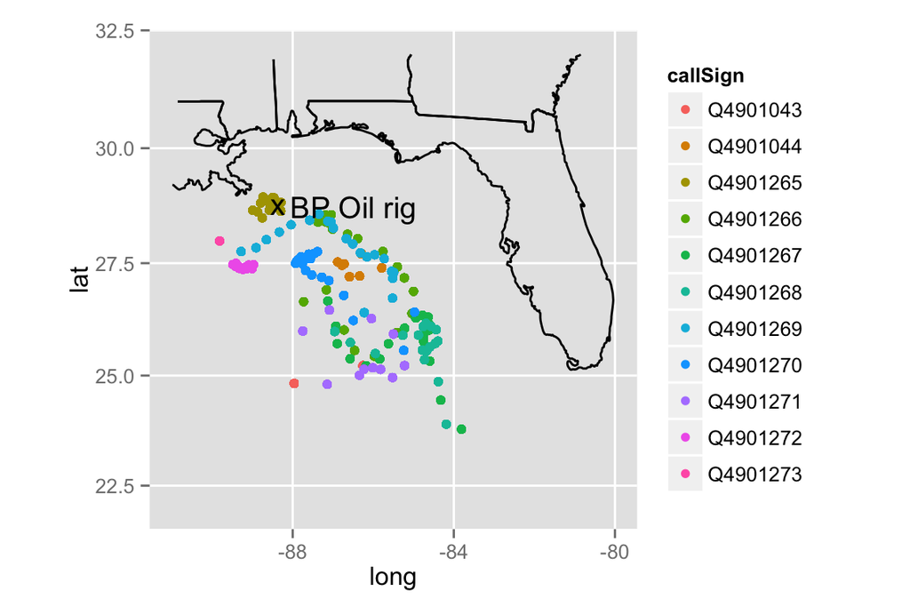

```r
map_floats +
  geom_point(data = rig, aes(x, y), shape = "x", size = 5) +
  geom_text(data = rig, aes(x, y), label = "BP Oil rig",
            size = 5, hjust = -0.1)
```

## Your Turn

- Use your ggplot2 skills to explore any (or all!) of the floats/gliders/boats data. Be creative!!

## How *exactly* does layering work?

## A simpler example

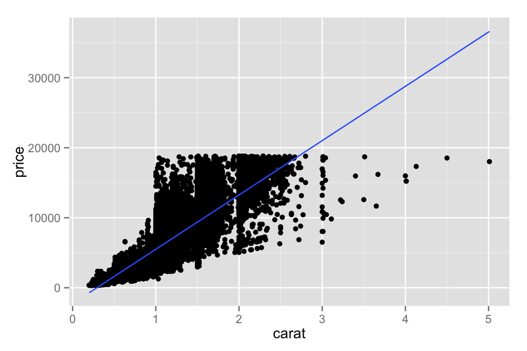

```r
p <- ggplot(data = diamonds, aes(x = carat, y = price)) +
  geom_point() +           # layer 1
  geom_smooth(method = lm) # layer 2
p
```

## Plot-level things

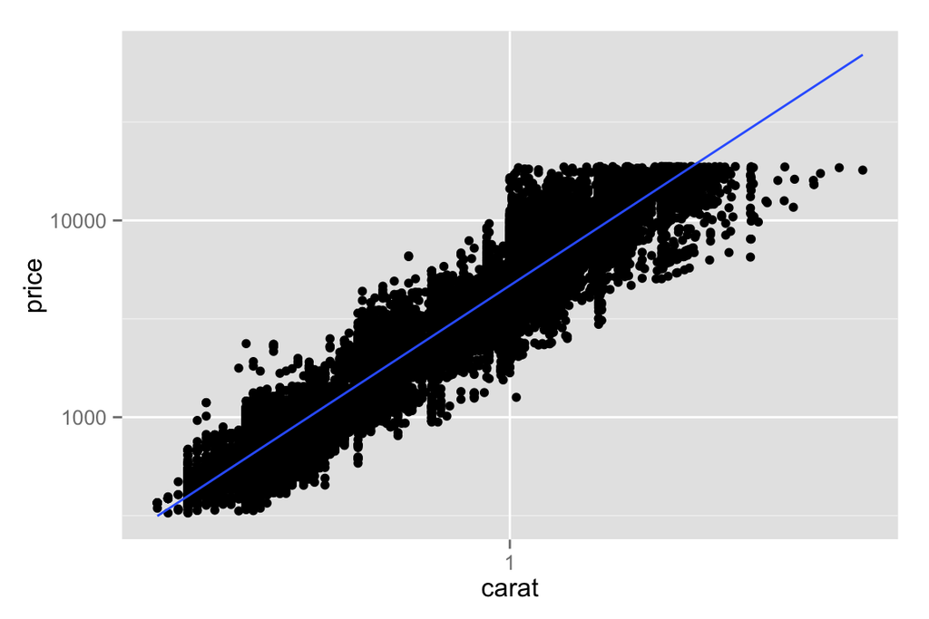

```r
# scales
p <- p + scale_x_log10() + scale_y_log10()
p
```

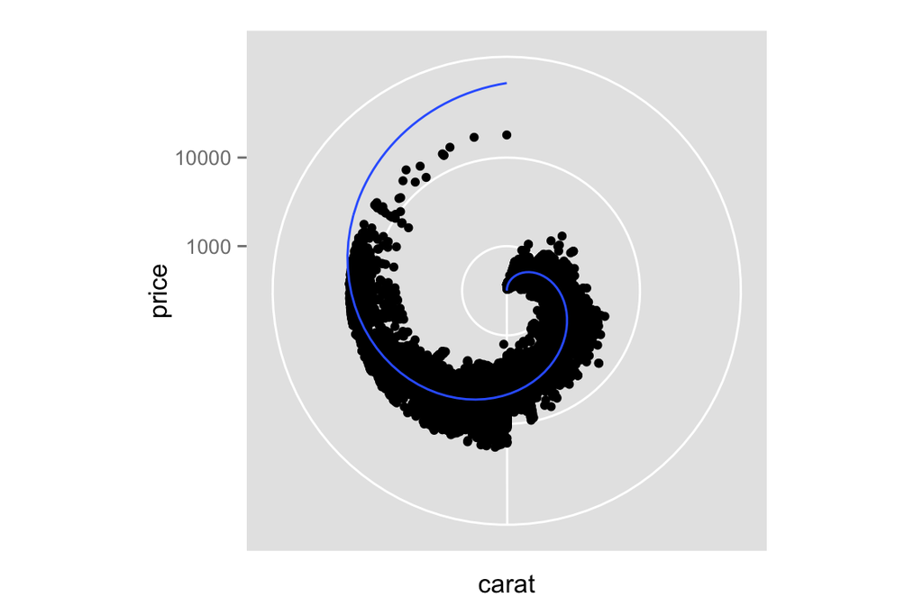

```r
# coordinate system
p + coord_polar()
```

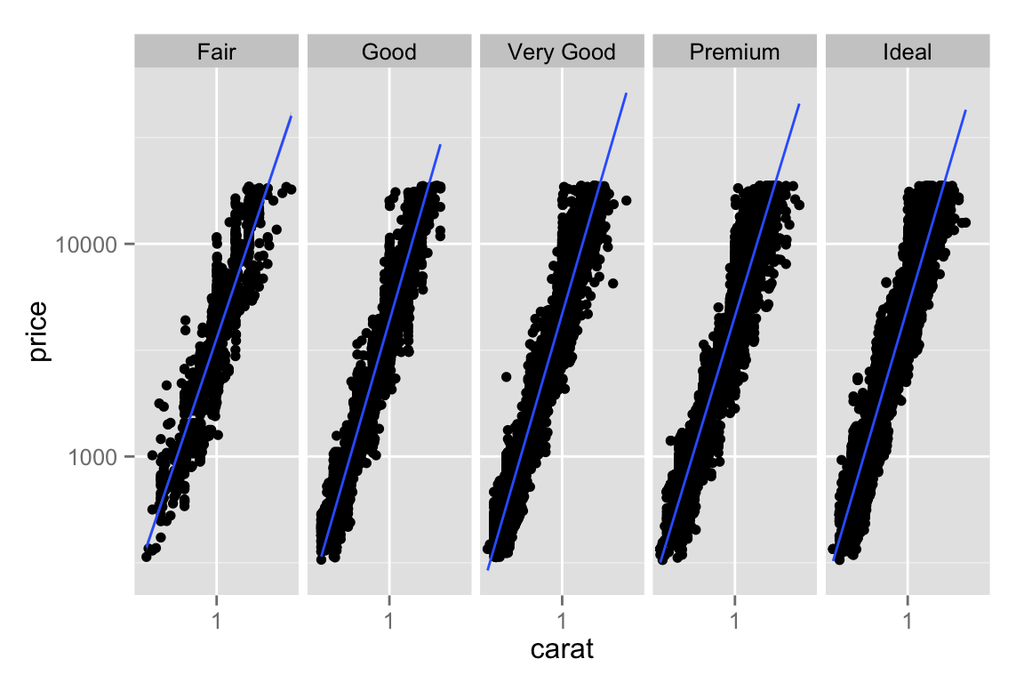

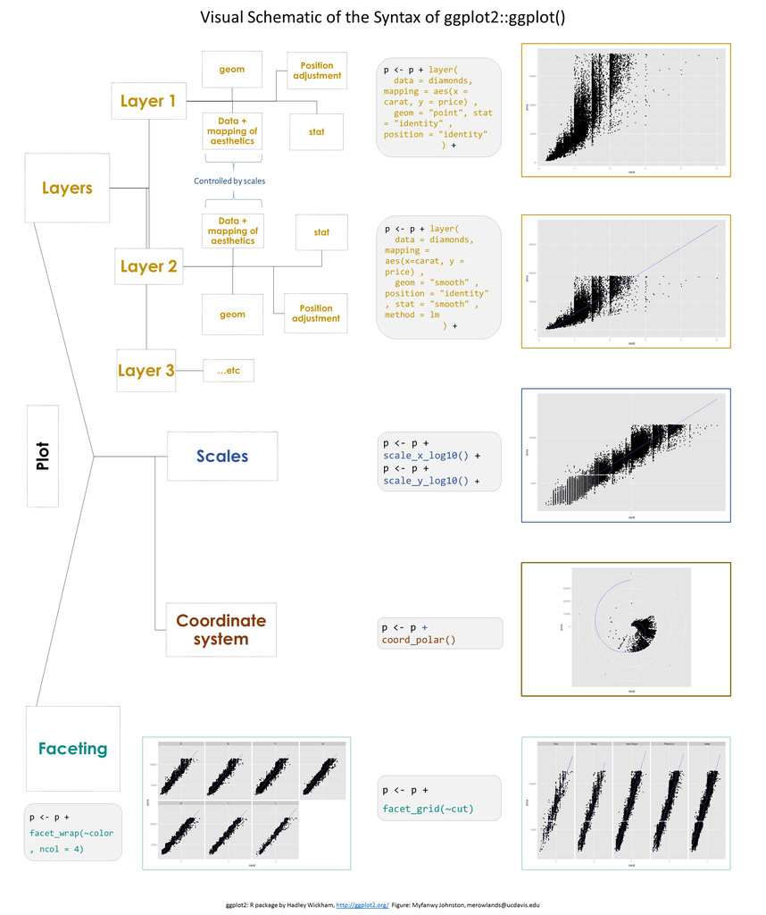

```r
# facets
p + facet_grid(. ~ cut)
```

- Each `geom_*` function is really a layer with certain defaults for statistic, position, and, well, geometry.

```r
args(geom_point)
```

```
## function (mapping = NULL, data = NULL, stat = "identity", position = "identity",
##     na.rm = FALSE, ...)
## NULL
```

```r
args(geom_smooth)
```

```
## function (mapping = NULL, data = NULL, stat = "smooth", position = "identity",
##     ...)
## NULL
```

```r
args(geom_bar)
```

```
## function (mapping = NULL, data = NULL, stat = "bin", position = "stack",
##     ...)
## NULL
```

## Defaults aren't always right!!

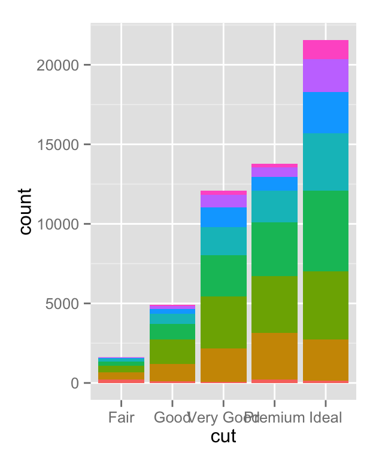

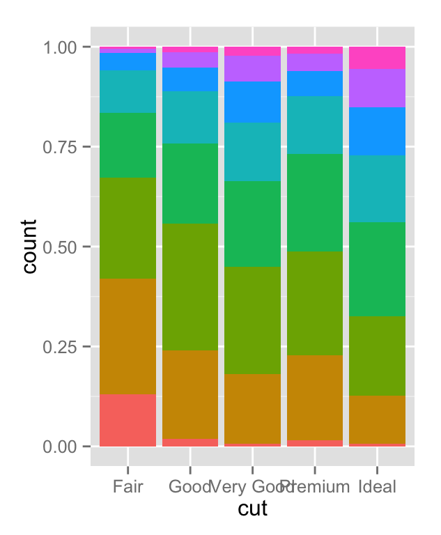

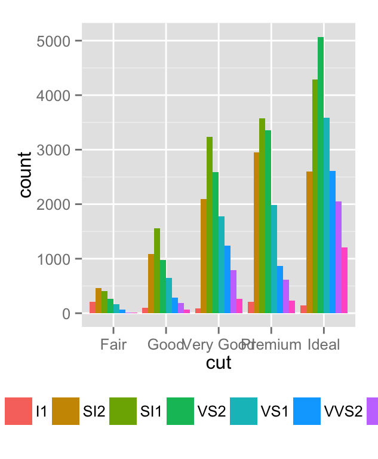

```r
base <- ggplot(diamonds, aes(x = cut, fill = clarity)) + theme(legend.position = "none")
base + geom_bar()                                   # bad!!!
base + geom_bar(position = "fill")                  # better
base + geom_bar(position = "dodge") +
  theme(legend.position = "bottom")                 # better
```

## Your Turn

- Read in the animal.csv data

```r
animals <- read.csv("http://heike.github.io/rwrks/02-r-graphics/data/animal.csv")
```

- Plot the location of animal sightings on a map of the region
- On this plot, try to color points by class of animal and/or status of animal
- Advanced: Could we indicate time somehow?